# Assignment **Lab-2** Visulization of Data:

In this **Lab-2 assignment** we are trying to visulize the data using different python libraries such as *Matplotlib, Seaborn, and Plotly*.

`Find More information from below...`

- Go to tutorial of [Matplotlib](https://matplotlib.org/stable/tutorials/index.html).
- Reference to [Seaborn](https://seaborn.pydata.org/tutorial.html) documentation.
- Quick start Guide to [Plotly](https://plotly.com/python/)

`Lab-2 by OmPatel ID:8958837`

[figure not shown]

## Implementation of Matplotlib:

Matplotlib is a comprehensive library in Python used for creating static, animated, and interactive visualizations in a wide range of formats. In the following cell we will plot the data **"Generated using Mathematical formula"** in 3D form. One simple chart is also generated.

```python
%matplotlib notebook
```

[output not shown]

[output cut: 12 more lines]

[output not shown]

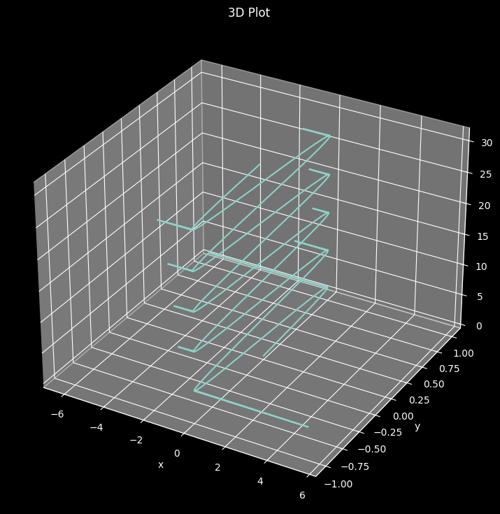

```python
import numpy as np
import matplotlib.pyplot as plt
plt.style.use('dark_background')

fig = plt.figure(figsize = (9,9))
ax = plt.axes(projection = '3d')
ax.grid()

t = np.arange(0, 10*np.pi, np.pi/50)
x = np.tan(t)
y = np.sin(t)

ax.plot3D(x,y,t)
ax.set_title('3D Plot')

# set axes label
ax.set_xlabel('x')
ax.set_ylabel('y')
ax.set_zlabel('t')

plt.show()
```

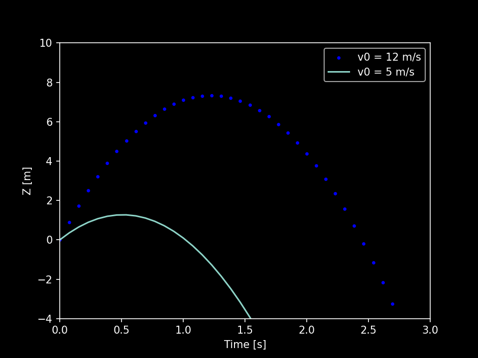

```python
import matplotlib.animation as animation

fig, ax = plt.subplots()
t = np.linspace(0, 3, 40)
g = -9.81
v0 = 12
z = g * t**2 / 2 + v0 * t

v02 = 5
z2 = g * t**2 / 2 + v02 * t

scat = ax.scatter(t[0], z[0], c="b", s=5, label=f'v0 = {v0} m/s')
line2 = ax.plot(t[0], z2[0], label=f'v0 = {v02} m/s')[0]
ax.set(xlim=[0, 3], ylim=[-4, 10], xlabel='Time [s]', ylabel='Z [m]')
ax.legend()


def update(frame):
    # for each frame, update the data stored on each artist.
    x = t[:frame]
    y = z[:frame]
    # update the scatter plot:
    data = np.stack([x, y]).T
    scat.set_offsets(data)
    # update the line plot:
    line2.set_xdata(t[:frame])
    line2.set_ydata(z2[:frame])
    return (scat, line2)


ani = animation.FuncAnimation(fig=fig, func=update, frames=40, interval=30)
plt.show()
```

[figure not shown]

## Seaborn for Visualization:

Seaborn is a library for making statistical graphics in Python. It builds on top of matplotlib and integrates closely with pandas data structures.Seaborn helps you explore and understand your data. Its plotting functions operate on dataframes and arrays containing whole datasets and internally perform the necessary semantic mapping and statistical aggregation to produce informative plots.

We are using an in-build dataset called tips for this visualization program.

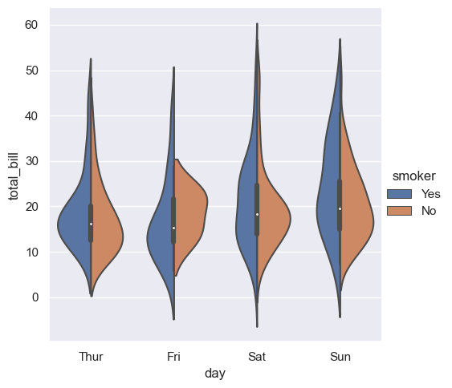

```python
import seaborn as sns

sns.set_theme()
tips = sns.load_dataset("tips")
sns.catplot(data=tips, kind="violin", x="day", y="total_bill", hue="smoker", split=True)
```

## Plotly as a Visualization tool:

Plotly's Python graphing library makes interactive, publication-quality graphs. Examples of how to make line plots, scatter plots, area charts, bar charts, error bars, box plots, histograms, heatmaps, subplots, multiple-axes, polar charts, and bubble charts. Plotly.py is free and open source and you can view the source code.

```python
import plotly.graph_objects as go

fig = go.Figure(data =
     go.Contour(
        z=[[10, 10.625, 12.5, 15.625, 20],
           [5.625, 6.25, 8.125, 11.25, 15.625],
           [2.5, 3.125, 5., 8.125, 12.5],
           [0.625, 1.25, 3.125, 6.25, 10.625],
           [0, 0.625, 2.5, 5.625, 10]],
        colorscale='Electric',
    ))
fig.show()
```

[output not shown]

### Now, Let's compare all three packages by making table.

| Feature | Matplotlib | Seaborn | Plotly |
| --- | --- | --- | --- |
| **Ease of Use** | Versatile but requires more code for customization | Designed for simplicity with concise syntax | User-friendly with interactive features |
| **Plot Types** | Supports a wide range of plot types | Primarily focused on statistical plots | Comprehensive support for various charts |
| **Aesthetics** | Customization requires more effort | Stylish default themes and color palettes | Modern and aesthetically pleasing visuals |
| **Default Styles** | Basic default styles | More visually appealing default styles | Modern and appealing default styles |
| **Integration with Pandas** | Works well with Pandas data structures | Seamlessly integrates with Pandas DataFrames | Direct integration with Pandas DataFrames |
| **Interactive Features** | Limited interactivity (can be enhanced with other libraries) | Limited interactivity (focuses on static plots) | Rich interactivity and dynamic visualizations |
| **Documentation** | Extensive and well-documented | Comprehensive documentation | Detailed documentation with examples |
| **Community Support** | Large and active community | Growing community | Active community and strong support |
| **Backend Technology** | Built on NumPy arrays for data manipulation | Extends Matplotlib and integrates with NumPy | Utilizes JavaScript for interactive plots |
| **Usage** | Widely used in diverse fields | Often used for statistical data analysis | Popular for web-based and interactive apps |